# Final Exam on Scorpion Behavior

Briana Jefferson

June 02, 2016

# Introduction

Investigate whether the odors from a predator might influence the defensive behavior of Hadrurus arizonensis, and if the scorpion size plays a role in the type of response.

We see this as two questions:

- **Does presence of odor change the expected outcome on our measurements?**
- **Does size of the scorpion change the expected outcome on our measurements?**

We were given two comma separated values files containing these measurements

A data frame with 60 observations on the following 7 variables:

- **Scorpion** - a tag indicating which scorpion was measured.
- **Behavior** - a factor variable [no sting, dry sting, wet sting, jab].
- **Volume** - a numerical measure of venom amount (wet sting).
- **Probes** - a numerical count of the number of “hits” applied to get a reaction.
- **Reaction Time** - a numerical measure of time it took to get a reaction.
- **size** - a factor (large, small) of scorpion size.
- **roll** - a factor (control, threat) of absence or presence of an apparent threat to the scorpion (rat urine).

There were 30 different scorpions tested. Each scorpion was tested twice, once in control (no rat urine present), and once in threat (rat urine ) the order of testing was randomly assigned.

One of the csv files refers to the individual tests run. It has 60 observations. The other is conveiently organized as paired data with obsevations of each scorpion in both threat and control conditions for conveinence in paired tests.

In order to answer our questions, a analysis shows we should be using the variables: Behavior, size, and roll. This is important as it guides us to show how we answer the questions.

# Methods for presence vs absence of odor

The methods we use for this problem involve explaining the categorical variables (Behavior, roll). We will use a bar chart as our graphical tool, rowPerc as our numerical tool, and Chi-square test as our inferential methods. To deal with the question if the presence of odor would change the expected outcome, we will use this definition:

- **Jab** - used back of telson. The stinger part not used.
- **Dry sting** - Stinger was used but no venom was delivered.
- **Wet sting** - Stinger was used and venom was delivered.
- **No sting** - Stinger not used.

# Results

## Descriptive Results

### Graphical Descriptive Results

```
First, we will look at a barchart to answer.
```

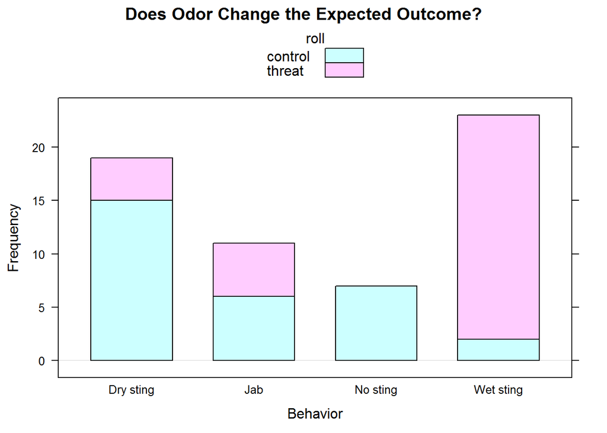

```r
url2="scorpion_reaction_rolls.csv"
scorp_data2=read.csv(url2,header=T)
contTable <- xtabs(~ Behavior + roll, data = scorp_data2)
barchart(contTable,
    auto.key = list(
        space = "top",
        title = "roll",
        cex.title = 1,
        columns = 1),
    horizontal = FALSE,
    main = "Does Odor Change the Expected Outcome?",
    xlab = "Behavior",
    ylab = "Frequency")
```

- The bar graph clearly shows that the scorpions are much more likely to have a wet sting when a threat is present, than in the control group when the threat is not present.

### Numerical Descriptive Results

```
We will consider comparing row percent.
```

```r
attach(scorp_data2)
rol=table(roll,Behavior)
rowPerc(rol)
```

```
##          Behavior
## roll      Dry sting    Jab No sting Wet sting  Total
##   control     50.00  20.00    23.33      6.67 100.00
##   threat      13.33  16.67     0.00     70.00 100.00
```

- The row percent test definitely shows the scorpions are more likely to have a wet sting when a threat is present as opposed to when there is no threat present. About 70% of the scorpions will have a wet sting when the threat is present. While those who did not have a threat present, had about 7% with a wet sting.

## Inferential Results

```
We will use a Chi-squared test to answer.
```

```r
chisqtestGC(rol,simulate.p.value = TRUE)
```

```
## Pearson's chi-squared test with simulated p-value
##   (based on 2000 resamples)
##
## Observed Counts:
##          Behavior
## roll      Dry sting Jab No sting Wet sting
##   control        15   6        7         2
##   threat          4   5        0        21
##
## Counts Expected by Null:
##          Behavior
## roll      Dry sting Jab No sting Wet sting
##   control       9.5 5.5      3.5      11.5
##   threat        9.5 5.5      3.5      11.5
##
## Contributions to the chi-square statistic:
##          Behavior
## roll      Dry sting  Jab No sting Wet sting
##   control      3.18 0.05     3.50      7.85
##   threat       3.18 0.05     3.50      7.85
##
##
## Chi-Square Statistic = 29.155
## Degrees of Freedom of the table = 3
## P-Value = 5e-04
```

- The Chi-Square test shows that we would reject the null hypothesis based on the fact that the wet sting was used more frequently with the threat presence in comparison to when there is no threat present. The P-Value is significantly low which indicates that there is a difference between the two variables compared.

# Methods for Different Sizes (large vs small)

The methods we use for this problem involve explaining the categorical variables (Behavior, roll, size). We will use bar chart as our graphical tool, rowPerc as our numerical tool, and t-tests as our inferential methods. To deal with the question if size makes a difference with the presence of odor, we will use this definition:

- **Jab** - used back of telson. The stinger part not used.
- **Dry sting** - Stinger was used but no venom was delivered.
- **Wet sting** - Stinger was used and venom was delivered.
- **No sting** - Stinger not used.

# Results

## Descriptive Results

To understand if we have a difference in outcome based on size, we have to compare the scorpions when an odor is a factor to see if they would attack or become more aggravated. We will create a plot in order to understand if there is a difference in size when the scorpion feels threatened by a predator or if they do not feel threatened by a predator. We will create a row percent to see if there is a relationship between the size of a scorpion when it feels threatened by a predator or if they do not feel threatened by a predator. We will also produce a t.test in order to show the comparison in the sizes between the control group and the experimental group.

### Graphical Descriptive Results

```
First, we will look at a barchart to answer.
```

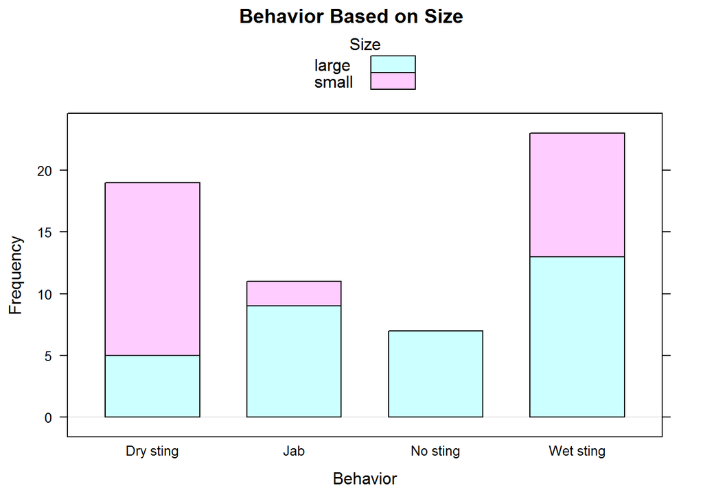

```r
contTable <- xtabs(~ Behavior + size, data = scorp_data2)
barchart(contTable,
    auto.key = list(
        space = "top",
        title = "Size",
        cex.title = 1,
        columns = 1),
    horizontal = FALSE,
    main = "Behavior Based on Size",
    xlab = "Behavior",
    ylab = "Frequency")
```

### Numerical Descriptive Results

```
We will consider comparing row percents.
```

```r
attach(scorp_data2)
rol=table(size,Behavior)
rowPerc(rol)
```

```
##        Behavior
## size    Dry sting    Jab No sting Wet sting  Total
##   large     14.71  26.47    20.59     38.24 100.00
##   small     53.85   7.69     0.00     38.46 100.00
```

## Inferential Results

```
We will use a t.test to answer.
```

```r
t.test(Reaction_Time ~ size, data = scorp_data2)
```

```
##
##  Welch Two Sample t-test
##
## data:  Reaction_Time by size
## t = 3.9224, df = 38.308, p-value = 0.000352
## alternative hypothesis: true difference in means is not equal to 0
## 95 percent confidence interval:
##  0.7797981 2.4423286
## sample estimates:
## mean in group large mean in group small
##           2.4302941           0.8192308
```

# Discussion and Conclusion for both set of research questions

**Does presence of odor change the expected outcome on our measurements?**

- When a scorpion is tested with the threat from the odor of rat urine, they are more likely to behave with a wet sting. When in a control test with no threat using the odor of rat urine, a scorpion has a smaller chance of behaving with a wet sting. In conclusion, the odor of rat urine does affect the scorpion behavior when threatened.